# Invasive plant species reduces insect feeding diversity and trophic interactions on a tropical volcanic island

#SCORE DTS

```r
library(dplyr)

leafdata <- leafdata %>%
  mutate(
    score = case_when(
      damage_type %in% c("DT1", "DT2", "DT3", "DT4", "DT5", "DT12", "DT13", "DT14", "DT15", "DT16",
                         "DT29", "DT30", "DT32", "DT34", "DT35", "DT36", "DT41", "DT46", "DT51", "DT64",
                         "DT66", "DT69", "DT81", "DT101", "DT145") ~ "1: General",
      damage_type %in% c("DT6", "DT8", "DT9", "DT24", "DT25", "DT45", "DT47", "DT52", "DT61", "DT63",
                         "DT67", "DT76", "DT109", "DT116", "DT119", "DT144", "DT79", "DT84", "DT85",
                         "DT90", "DT138", "DT72", "DT100", "DT101", "DT102", "MDT01") ~ "2: specialized",
      damage_type %in% c("DT37", "DT102", "MDT02", "MDT03", "MDT04", "MDT5", "MDT6", "MDT7") ~ "3: extremely specialized",
      damage_type %in% c("DT17", "DT20", "DT31", "DT33", "DT42", "DT43", "DT48", "DT54", "DT57", "DT58",
                         "DT59", "DT62", "DT68", "DT78", "DT79", "DT100", "DT104", "DT106", "DT122", "DT125",
                         "DT127", "DT128", "DT131", "DT146", "DT147") ~ "unscored",
      TRUE ~ NA_character_  # Assign NA if no match
    )
  )
```

#rename NAs

```r
library(tidyverse)
leafdata <- leafdata %>%
  mutate(herbivory_type = ifelse(is.na(herbivory_type), "Undamaged", herbivory_type),
         damage_type = ifelse(is.na(damage_type), "Undamaged", damage_type),
         score = ifelse(is.na(score), "Undamaged", score))
leafdata
```

| leaf | site | species | group | herbivory_type | damage_type | percent | notes: | score |
| --- | --- | --- | --- | --- | --- | --- | --- | --- |
| 1 | 4 | B. asiatica | N | skeletonization | 56 | 0.100 | NA | 2: specialized |
| 2 | 4 | B. asiatica | N | hole feeding | 1 | 0.010 | NA | 1: General |
| 3 | 4 | B. asiatica | N | Undamaged | 81 | 0.000 | NA | Undamaged |
| 4 | 4 | B. asiatica | N | margin feeding | 43 | 0.050 | NA | unscored |
| 4 | 4 | B. asiatica | N | mining | 37 | 0.150 | NA | 1: General |
| 5 | 4 | B. asiatica | N | margin feeding | 15 | 0.070 | NA | 1: General |
| 5 | 4 | B. asiatica | N | hole feeding | 31 | 0.020 | NA | 1: General |
| 6 | 4 | B. asiatica | N | Undamaged | 81 | 0.000 | NA | Undamaged |
| 7 | 4 | B. asiatica | N | Undamaged | 81 | 0.000 | NA | Undamaged |
| 8 | 4 | B. asiatica | N | hole feeding | 1 | 0.010 | NA | 1: General |

[output cut: 990 more lines]

##N, R, I TESTS #herb box plot code

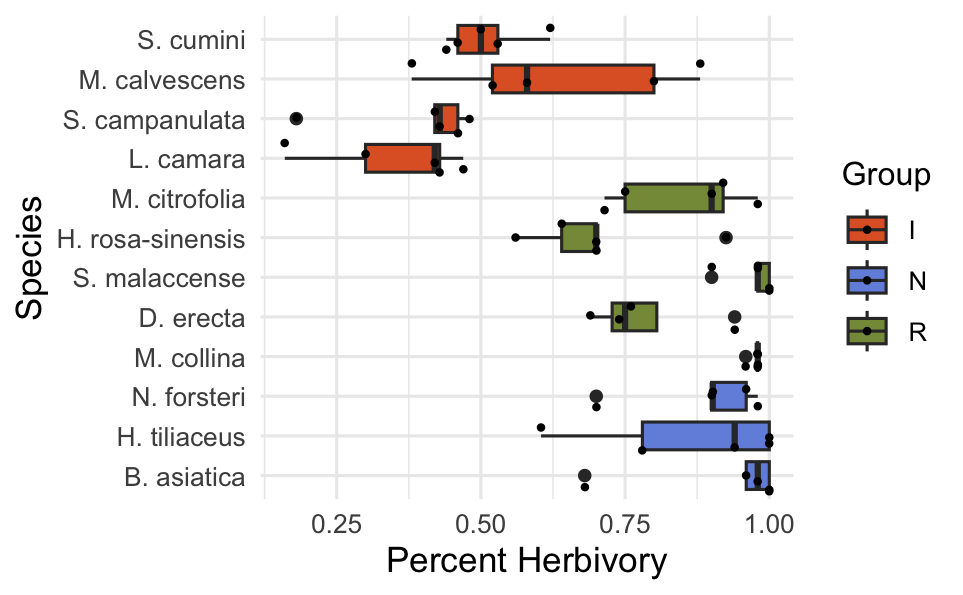

```r
##HERBIVORY PLOT CODE

library(tidyverse)
library(dplyr)

herb_data <- leafdata %>%
  group_by(leaf, site, species, group) %>%
  summarise(total_HI = sum(percent),
            .groups = "drop")

herb_data_plot <- herb_data %>%
  filter(!is.na(total_HI)) %>%
  group_by(group, species,site) %>%
  summarize(
    proportion_non_zero = sum(total_HI > 0.01) / n(),
    .groups = "drop"
  )


herb_data_plot$species <- factor(herb_data_plot$species, levels = c("B. asiatica", "H. tiliaceus", "N. forsteri", "M. collina", "D. erecta", "S. malaccense", "H. rosa-sinensis", "M. citrofolia", "L. camara", "S. campanulata", "M. calvescens", "S. cumini"))

library(ggplot2)
herb_percent_plot_bar <- ggplot(herb_data_plot, aes(x = species, y = proportion_non_zero, fill = group)) +
  geom_boxplot(position = position_dodge(width = 0.9), width = 0.7) +
  labs(x = "Species", y = "Percent Herbivory", fill = "Group") +
  scale_fill_manual(values = my_colors)+
  theme_minimal() +
  theme(axis.text=element_text(size=9),axis.title=element_text(size=12))+
  coord_flip()+
  geom_jitter(size= 0.7)


herb_percent_plot_bar

ggsave("herb_percent_plot_bar.png", plot = herb_percent_plot_bar,  width = 5.76, height = 5, units = "in")
```

# ANOVA CODE herbiv

```r
## ANOVA CODE
library(dplyr)

anova_herb_data <- herb_data %>%
  filter(!is.na(total_HI)) %>%  # Remove rows with NA values in total_HI
  group_by(site,species,group) %>%
  summarize(
    proportion_non_zero = sum(total_HI > 0.01) / n(),
    .groups = "drop"
  )

anova_herb_data
```

| site | species | group | proportion_non_zero |
| --- | --- | --- | --- |
| 1 | S. campanulata | I | 0.1800000 |
| 2 | H. tiliaceus | N | 0.6041667 |
| 3 | L. camara | I | 0.1600000 |
| 4 | B. asiatica | N | 0.6800000 |
| 5 | M. calvescens | I | 0.3800000 |
| 6 | N. forsteri | N | 0.7000000 |
| 7 | H. tiliaceus | N | 0.7800000 |
| 8 | H. rosa-sinensis | R | 0.7000000 |
| 9 | H. rosa-sinensis | R | 0.6400000 |
| 10 | M. calvescens | I | 0.5200000 |

[output cut: 49 more lines]

```r
herb_anova <- aov(anova_herb_data$proportion_non_zero ~ anova_herb_data$group, data=anova_herb_data)

summary(herb_anova)
```

```
                      Df Sum Sq Mean Sq F value  Pr(>F)
anova_herb_data$group  2  2.183  1.0916   51.71 1.9e-13
Residuals             56  1.182  0.0211

anova_herb_data$group ***
Residuals
---
Signif. codes:
0 ‘***’ 0.001 ‘**’ 0.01 ‘*’ 0.05 ‘.’ 0.1 ‘ ’ 1
```

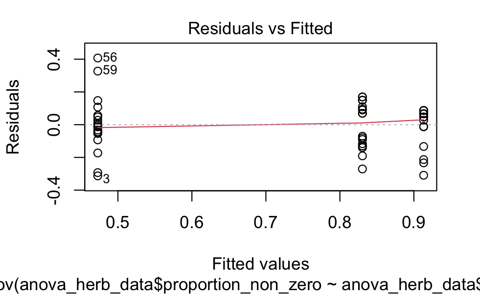

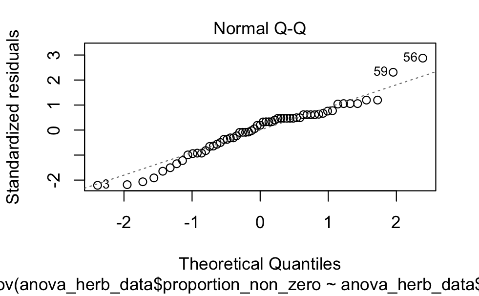

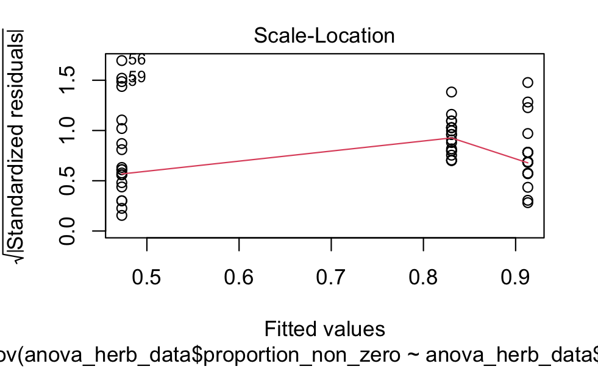

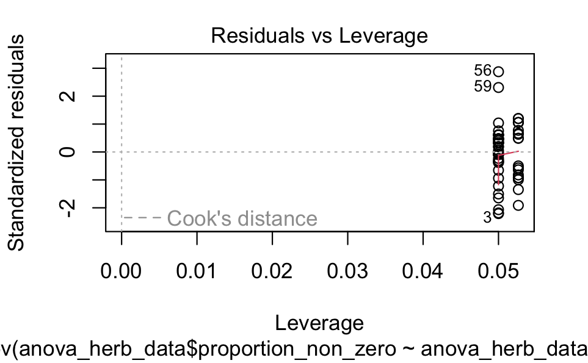

```r
plot(herb_anova)
```

```r
# Perform Tukey's HSD post-hoc test
tukey_herb <- TukeyHSD(herb_anova)

# Summary of the post-hoc test
print(tukey_herb)
```

```
  Tukey multiple comparisons of means
    95% family-wise confidence level

Fit: aov(formula = anova_herb_data$proportion_non_zero ~ anova_herb_data$group, data = anova_herb_data)

$`anova_herb_data$group`
           diff        lwr        upr     p adj
N-I  0.44042677  0.3298121 0.55104144 0.0000000
R-I  0.35769160  0.2456309 0.46975228 0.0000000
R-N -0.08273517 -0.1947958 0.02932551 0.1864345
```

```r
model_lm <- lm(proportion_non_zero ~ group, data = anova_herb_data)
summary(model_lm)$r.squared
```

```
[1] 0.6487385
```

#SHANNON DIVERSITY

```r
##SHANNON DIVERSITY
# Calculate Shannon Diversity for each plot
library(vegan)
library(dplyr)

# Convert "damage_type" to a factor to count occurrences
leafdata <- leafdata %>%
  mutate(damage_type = as.factor(damage_type))

# Calculate Shannon Diversity for each site
shannon_results <- leafdata %>%
  group_by(site) %>%
  summarize(ShannonIndex = diversity(table(damage_type), index = "shannon"))

diversity_data <- leafdata %>%
  group_by(site)

diversity_dat <- left_join(diversity_data, shannon_results, by = "site")

diversity_dat
```

| leaf | site | species | group | herbivory_type | damage_type | percent | notes: | score | ShannonIndex |
| --- | --- | --- | --- | --- | --- | --- | --- | --- | --- |
| 1 | 4 | B. asiatica | N | skeletonization | 56 | 0.100 | NA | 2: specialized | 2.520566 |
| 2 | 4 | B. asiatica | N | hole feeding | 1 | 0.010 | NA | 1: General | 2.520566 |
| 3 | 4 | B. asiatica | N | Undamaged | 81 | 0.000 | NA | Undamaged | 2.520566 |
| 4 | 4 | B. asiatica | N | margin feeding | 43 | 0.050 | NA | unscored | 2.520566 |
| 4 | 4 | B. asiatica | N | mining | 37 | 0.150 | NA | 1: General | 2.520566 |
| 5 | 4 | B. asiatica | N | margin feeding | 15 | 0.070 | NA | 1: General | 2.520566 |
| 5 | 4 | B. asiatica | N | hole feeding | 31 | 0.020 | NA | 1: General | 2.520566 |
| 6 | 4 | B. asiatica | N | Undamaged | 81 | 0.000 | NA | Undamaged | 2.520566 |
| 7 | 4 | B. asiatica | N | Undamaged | 81 | 0.000 | NA | Undamaged | 2.520566 |
| 8 | 4 | B. asiatica | N | hole feeding | 1 | 0.010 | NA | 1: General | 2.520566 |

[output cut: 990 more lines]

```r
diversity_anova <- aov(diversity_dat$ShannonIndex ~ diversity_dat$group, data=diversity_dat)

summary(diversity_anova)
```

```
                      Df Sum Sq Mean Sq F value Pr(>F)
diversity_dat$group    2  129.9   64.97   925.1 <2e-16
Residuals           5828  409.3    0.07

diversity_dat$group ***
Residuals
---
Signif. codes:
0 ‘***’ 0.001 ‘**’ 0.01 ‘*’ 0.05 ‘.’ 0.1 ‘ ’ 1
```

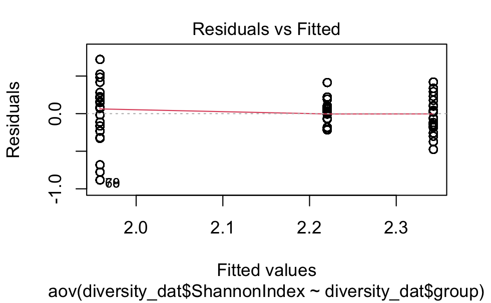

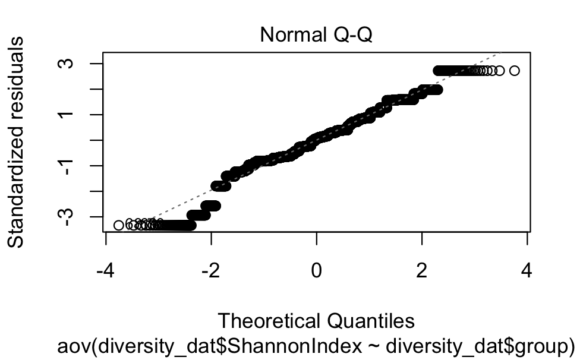

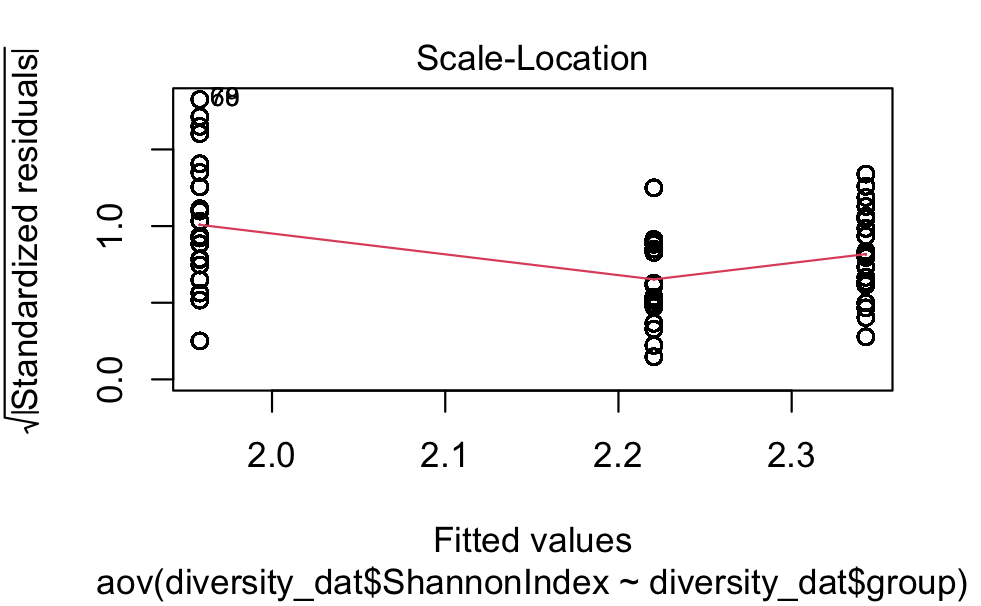

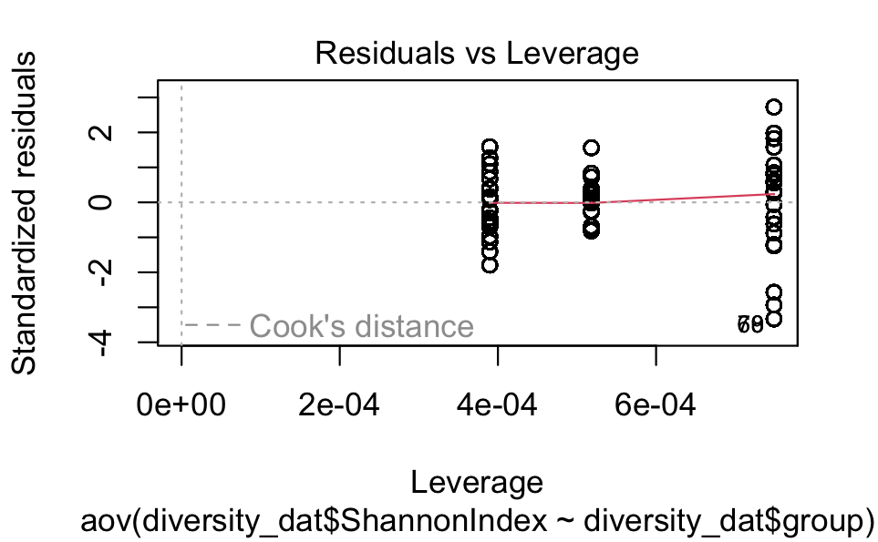

```r
plot(diversity_anova)
```

```r
# Perform Tukey's HSD post-hoc test
tukey_diversity_1 <- TukeyHSD(diversity_anova)

# Summary of the post-hoc test
print(tukey_diversity_1)
```

```
  Tukey multiple comparisons of means
    95% family-wise confidence level

Fit: aov(formula = diversity_dat$ShannonIndex ~ diversity_dat$group, data = diversity_dat)

$`diversity_dat$group`
          diff        lwr        upr p adj
N-I  0.3845072  0.3635422  0.4054722     0
R-I  0.2621147  0.2399991  0.2842303     0
R-N -0.1223925 -0.1411115 -0.1036735     0
```

#SHANON table

```r
# Calculate Shannon Diversity for each plot
library(vegan)
library(dplyr)

# Convert "damage_type" to a factor to count occurrences
leafdata <- leafdata %>%
  mutate(damage_type = as.factor(damage_type))

# Calculate Shannon Diversity for each site
shannon_results <- leafdata %>%
  group_by(group) %>%
  summarize(ShannonIndex = diversity(table(damage_type), index = "shannon"))
```

#Shannon Anova

```r
# Load required libraries
library(dplyr)

# Prepare the dataframe
shannon_dataframe <- diversity_dat %>%
  select(site, ShannonIndex, species, group) %>%
  distinct()

# Perform ANOVA on ShannonIndex by group
diversity_anova_2 <- aov(ShannonIndex ~ group, data = shannon_dataframe)

# View the ANOVA summary
summary(diversity_anova_2)
```

```
            Df Sum Sq Mean Sq F value  Pr(>F)
group        2  1.432  0.7158    7.67 0.00114 **
Residuals   56  5.226  0.0933
---
Signif. codes:
0 ‘***’ 0.001 ‘**’ 0.01 ‘*’ 0.05 ‘.’ 0.1 ‘ ’ 1
```

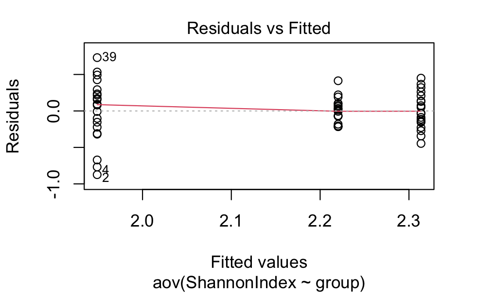

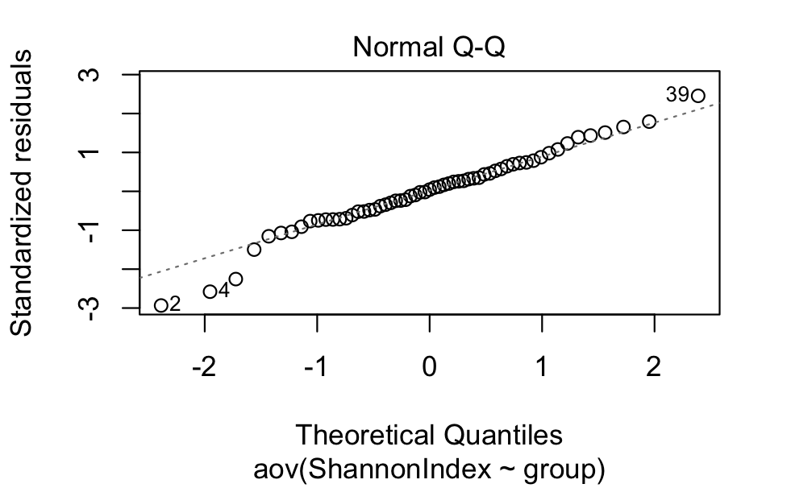

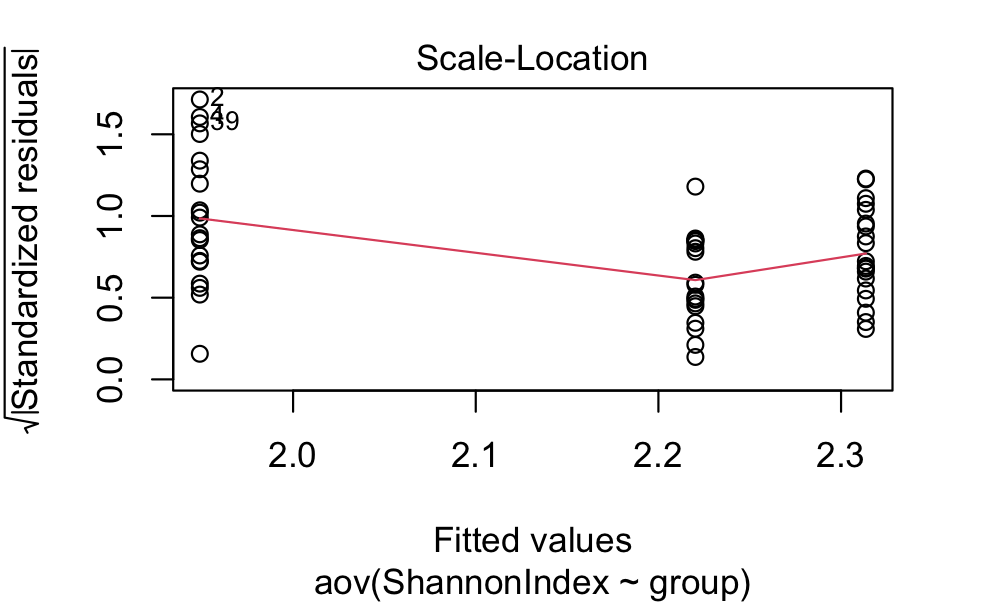

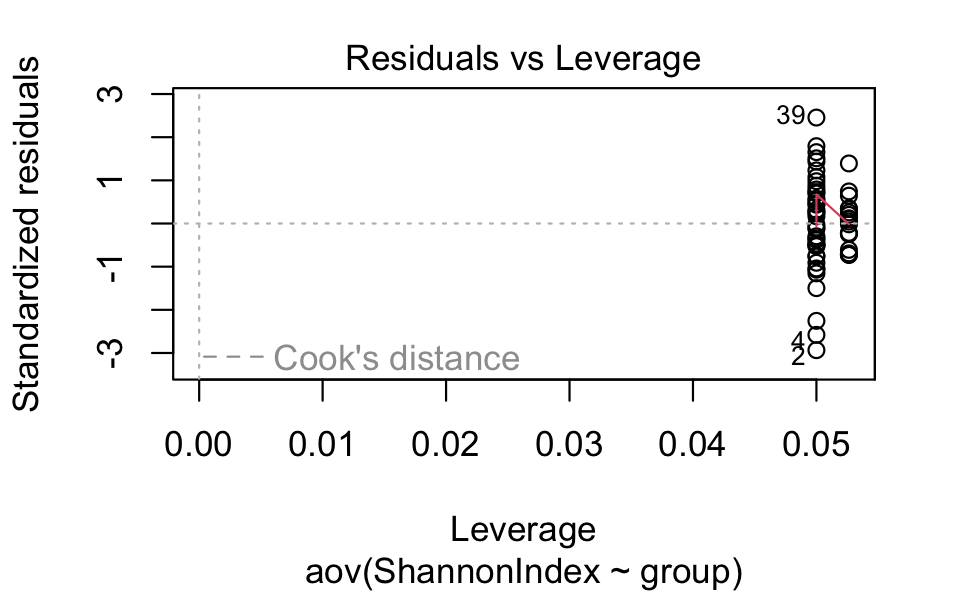

```r
# Plot the ANOVA results
plot(diversity_anova_2)
```

```r
# Perform Tukey's HSD post-hoc test
tukey_diversity <- TukeyHSD(diversity_anova_2)

# Print the summary of the post-hoc test
print(tukey_diversity)
```

```
  Tukey multiple comparisons of means
    95% family-wise confidence level

Fit: aov(formula = ShannonIndex ~ group, data = shannon_dataframe)

$group
           diff         lwr       upr     p adj
N-I  0.36463537  0.13204841 0.5972223 0.0011184
R-I  0.27130662  0.03567918 0.5069341 0.0203165
R-N -0.09332875 -0.32895619 0.1422987 0.6089813
```

```r
# Fit a linear model to calculate R-squared
model_lm <- lm(ShannonIndex ~ group, data = shannon_dataframe)

# Calculate and print the R-squared value
r_squared <- summary(model_lm)$r.squared
print(paste("R-squared: ", round(r_squared, 4)))
```

```
[1] "R-squared:  0.215"
```

#shannon plot code

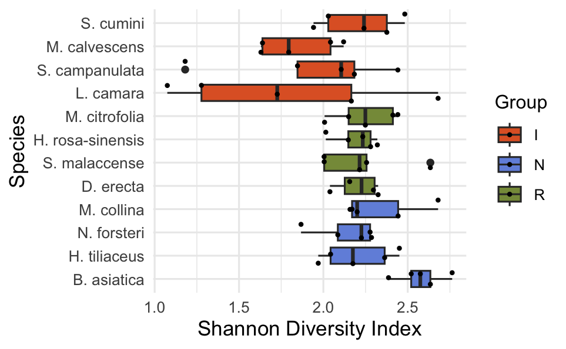

```r
library(tidyverse)
library(dplyr)
library(vegan)
my_colors <- c("N" = "#7392de", "R" = "#869948", "I" = "#e0632d")

shannon_dataframe$species <- factor(shannon_dataframe$species, levels = c("B. asiatica", "H. tiliaceus", "N. forsteri", "M. collina", "D. erecta", "S. malaccense", "H. rosa-sinensis", "M. citrofolia", "L. camara", "S. campanulata", "M. calvescens", "S. cumini"))

shannon_plots <- ggplot(shannon_dataframe, aes(x = species, y = ShannonIndex, fill = group)) +
 geom_boxplot(position = position_dodge(width = 0.9), width = 0.7) +
  labs( x = "Species", y = "Shannon Diversity Index", fill = "Group") +
  scale_fill_manual(values = my_colors) +
  theme_minimal() +
  theme(axis.text=element_text(size=9),axis.title=element_text(size=12))+
  coord_flip()+
  geom_jitter(size = 0.7)


ggsave("shannon_plot.png", plot = shannon_plots, width = 5.76, height = 5, units = "in")
shannon_plots
```

#functional feeding groups proportion

```r
proportions_funcfeed <- leafdata%>%
  group_by(site, species, group, herbivory_type) %>%
  summarize(count = n()) %>%
  group_by(site) %>%
  mutate(percentage = count / sum(count))
type_anova <- aov(percentage ~ group*proportions_funcfeed$herbivory_type, data = proportions_funcfeed)

summary(type_anova)
```

```
                                           Df Sum Sq
group                                       2  0.126
proportions_funcfeed$herbivory_type        11  1.655
group:proportions_funcfeed$herbivory_type  18  0.711
Residuals                                 359  3.692
                                          Mean Sq F value
group                                     0.06295   6.121
proportions_funcfeed$herbivory_type       0.15043  14.627
group:proportions_funcfeed$herbivory_type 0.03953   3.843
Residuals                                 0.01028
                                            Pr(>F)
group                                      0.00243 **
proportions_funcfeed$herbivory_type        < 2e-16 ***
group:proportions_funcfeed$herbivory_type 3.56e-07 ***
Residuals
---
Signif. codes:
0 ‘***’ 0.001 ‘**’ 0.01 ‘*’ 0.05 ‘.’ 0.1 ‘ ’ 1
```

```r
tukey <- TukeyHSD(type_anova)

model_lm <- lm(percentage ~ group * herbivory_type, data = proportions_funcfeed)

# Calculate and print the R-squared value
r_squared <- summary(model_lm)$r.squared
print(paste("R-squared: ", round(r_squared, 4)))
```

```
[1] "R-squared:  0.403"
```

#count of funcfeed

```r
funcfeed_count <- leafdata%>%
  group_by(site, species, group, herbivory_type) %>%
  summarize(count = n()) %>%
  group_by(site)
type_anova_count <- aov(count ~ group*herbivory_type, data = funcfeed_count)

summary(type_anova_count)
```

```
                      Df Sum Sq Mean Sq F value   Pr(>F)
group                  2   1377   688.5   6.636  0.00148
herbivory_type        11  19836  1803.3  17.380  < 2e-16
group:herbivory_type  18   8931   496.2   4.782 1.37e-09
Residuals            359  37248   103.8

group                **
herbivory_type       ***
group:herbivory_type ***
Residuals
---
Signif. codes:
0 ‘***’ 0.001 ‘**’ 0.01 ‘*’ 0.05 ‘.’ 0.1 ‘ ’ 1
```

```r
tukey <- TukeyHSD(type_anova_count)
model_lm <- lm(count ~ group * herbivory_type, data = funcfeed_count)

# Calculate the R-squared value
r_squared <- summary(model_lm)$r.squared
print(r_squared)
```

```
[1] 0.4472977
```

#funcfeed test

```r
tukey_result
```

```
  Tukey multiple comparisons of means
    95% family-wise confidence level

Fit: aov(formula = proportion ~ group * Type_of_Herbivory_Group, data = shaped_proportions_type)

$group
             diff           lwr           upr     p adj
N-I  0.0008796376  0.0005749448  1.184330e-03 0.0000000
R-I  0.0004977555  0.0001890796  8.064314e-04 0.0004857
R-N -0.0003818821 -0.0006905580 -7.320619e-05 0.0105509

$Type_of_Herbivory_Group
                                              diff
galling-fungal                        6.249473e-04
hole feeding-fungal                   3.508425e-03
incertae sedia-fungal                -7.528435e-04
margin feeding-fungal                 3.066602e-03
mining-fungal                         7.673772e-04
oviposition-fungal                   -5.522790e-04
ovipositon-fungal                    -6.714550e-04
piercing and sucking-fungal          -2.674193e-04
skeletonization-fungal               -4.883309e-04
surface feeding-fungal                2.057966e-03
Undamaged-fungal                      5.871598e-04
hole feeding-galling                  2.883478e-03
incertae sedia-galling               -1.377791e-03
margin feeding-galling                2.441655e-03
mining-galling                        1.424299e-04
oviposition-galling                  -1.177226e-03
ovipositon-galling                   -1.296402e-03
piercing and sucking-galling         -8.923666e-04
skeletonization-galling              -1.113278e-03
surface feeding-galling               1.433019e-03
Undamaged-galling                    -3.778751e-05
incertae sedia-hole feeding          -4.261269e-03
margin feeding-hole feeding          -4.418232e-04
mining-hole feeding                  -2.741048e-03
oviposition-hole feeding             -4.060704e-03
ovipositon-hole feeding              -4.179880e-03
piercing and sucking-hole feeding    -3.775844e-03
```

[output cut: 1232 more lines]

[output not shown]

#damage specificity Anova

```r
##DAMAGE INTENSITY DIVERSITY
library(dplyr)

proportions_by_site <- leafdata%>%
  group_by(site, species, group, score) %>%
  summarize(count = n()) %>%
  group_by(site) %>%
  mutate(percentage = count / sum(count))
intensity_anova <- aov(proportion ~ group*intensity, data = shaped_proportions)

summary(intensity_anova)
```

```
                 Df   Sum Sq   Mean Sq F value   Pr(>F)
group             2 0.000342 0.0001712   18.77 3.48e-08
intensity         3 0.004498 0.0014993  164.40  < 2e-16
group:intensity   6 0.000705 0.0001175   12.88 2.98e-12
Residuals       196 0.001788 0.0000091

group           ***
intensity       ***
group:intensity ***
Residuals
---
Signif. codes:
0 ‘***’ 0.001 ‘**’ 0.01 ‘*’ 0.05 ‘.’ 0.1 ‘ ’ 1
```

```r
# Perform Tukey's HSD post-hoc test
tukey_intensity <- TukeyHSD(intensity_anova)

# Summary of the post-hoc test
print(tukey_intensity)
```

```
  Tukey multiple comparisons of means
    95% family-wise confidence level

Fit: aov(formula = proportion ~ group * intensity, data = shaped_proportions)

$group
             diff           lwr          upr     p adj
N-I  0.0029760862  0.0018031304 0.0041490420 0.0000000
R-I  0.0021193868  0.0008726668 0.0033661068 0.0002490
R-N -0.0008566995 -0.0020884163 0.0003750174 0.2303007

$intensity
              diff           lwr           upr     p adj
2-1  -0.0107981076 -0.0123328043 -0.0092634110 0.0000000
3-1  -0.0102489862 -0.0117836829 -0.0087142895 0.0000000
NA-1 -0.0111014684 -0.0126361651 -0.0095667717 0.0000000
3-2   0.0005491214 -0.0009855753  0.0020838181 0.7903405
NA-2 -0.0003033608 -0.0018380575  0.0012313359 0.9561076
NA-3 -0.0008524822 -0.0023871789  0.0006822145 0.4764140

$`group:intensity`
                   diff           lwr           upr
N:1-I:1    8.733979e-03  0.0054479916  1.201997e-02
R:1-I:1    7.199592e-03  0.0037069571  1.069223e-02
I:2-I:1   -6.822417e-03 -0.0101525139 -3.492321e-03
N:2-I:1   -4.024555e-03 -0.0073105421 -7.385676e-04
R:2-I:1   -5.886138e-03 -0.0093787724 -2.393503e-03
I:3-I:1   -6.922258e-03 -0.0102523542 -3.592161e-03
N:3-I:1   -3.719779e-03 -0.0070057666 -4.337921e-04
R:3-I:1   -4.248758e-03 -0.0077413922 -7.561229e-04
I:NA-I:1  -4.126731e-03 -0.0074568270 -7.966341e-04
N:NA-I:1  -6.956706e-03 -0.0102426928 -3.670718e-03
R:NA-I:1  -6.458555e-03 -0.0099511898 -2.965921e-03
R:1-N:1   -1.534387e-03 -0.0049849909  1.916217e-03
I:2-N:1   -1.555640e-02 -0.0188423836 -1.227041e-02
N:2-N:1   -1.275853e-02 -0.0159998116 -9.517256e-03
R:2-N:1   -1.462012e-02 -0.0180707204 -1.116951e-02
I:3-N:1   -1.565624e-02 -0.0189422238 -1.237025e-02
N:3-N:1   -1.245376e-02 -0.0156950361 -9.212480e-03
R:3-N:1   -1.298274e-02 -0.0164333402 -9.532133e-03
```

[output cut: 100 more lines]

```
N:3-I:3   0.0637466
R:3-I:3   0.3265288
I:NA-I:3  0.1982417
N:NA-I:3  1.0000000
R:NA-I:3  0.9999993
R:3-N:3   0.9999969
I:NA-N:3  0.9999997
N:NA-N:3  0.0506568
R:NA-N:3  0.2728640
I:NA-R:3  1.0000000
N:NA-R:3  0.2892383
R:NA-R:3  0.6902839
N:NA-I:NA 0.1682834
R:NA-I:NA 0.5455048
R:NA-N:NA 0.9999983
```

```r
model_lm <- lm(proportion ~ group * intensity, data = shaped_proportions)

# Calculate the R-squared value
r_squared <- summary(model_lm)$r.squared
print(r_squared)
```

```
[1] 0.7562183
```

#specificity plot

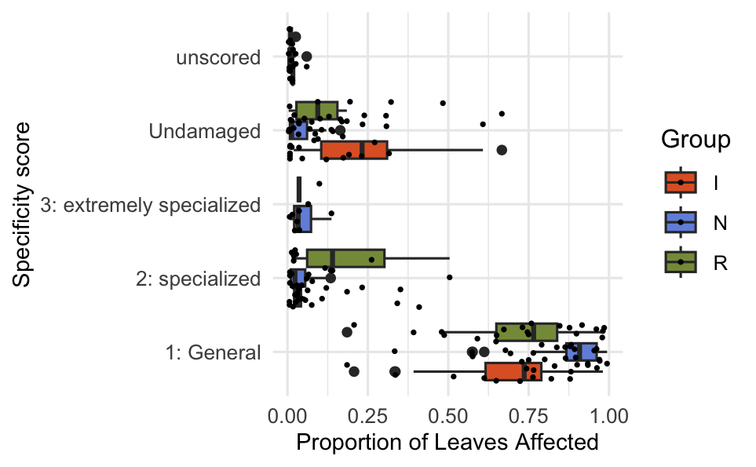

```r
library(ggplot2)
library(dplyr)

specificty_plot <- ggplot(proportions_by_site, aes(x = score, y = percentage, fill = group)) +
  geom_boxplot(position = position_dodge(width = 0.8), width = 0.7) +
  labs(x = "Specificity score", y = "Proportion of Leaves Affected", fill = "Group") +
  scale_fill_manual(values = c("N" = "#7392de", "R" = "#869948", "I" = "#e0632d", "NA" = "grey"))+
  theme_minimal() +
  theme(axis.text=element_text(size=9),axis.title=element_text(size=10))+
  coord_flip()+
  geom_jitter(size = 0.5)

specificty_plot

ggsave("specificty_plot.pdf", plot = specificty_plot,  width = 5.76, height = 5, units = "in")
```

```r
NA
NA
```

#functional feeding plot

```r
library(ggplot2)
library(RColorBrewer)
my_colors <- c("N" = "#7392de", "R" = "#869948", "I" = "#e0632d")
herb_cat_plot <- ggplot(leafdata, aes(x = herbivory_type, fill = group)) +
  geom_bar(position = position_dodge(width = 0.6), width = 0.5) +
  theme(axis.text.x = element_text(angle = 45, hjust = 1), plot.title = element_text(hjust = 0.5)) +
  labs( x = "Funcational Feeding Group", y = "Count", fill = "Group") +
   scale_fill_manual(values = my_colors) +
  theme_minimal()

ggsave("herb_cat_plot.png", plot = herb_cat_plot, width = 16, height = 6, units = "in")
```

#rarefaction

```r
library(vegan)
library(ggplot2)
library(tidyverse)

# read in leaf data
leaf <- read_csv("leafdata.csv")

# damage types per group to check
leaf %>% group_by(group, damage_type) %>% count() %>% ungroup(damage_type) %>% count()

# convert each row to a single leaf with damage types across columns, observed damage types noted as a "1"
leaf_wide <- leaf %>%
  pivot_wider(id_cols = c("leaf","group"),
              names_from = "damage_type",
              values_from = "damage_type",
              values_fn = function(x) sum(!is.na(x)), values_fill = 0) %>%
  select(-`NA`)

# subset for each group
leaf_wide_I <- leaf_wide %>% filter(group == "I")
leaf_wide_N <- leaf_wide %>% filter(group == "N")
leaf_wide_R <- leaf_wide %>% filter(group == "R")

# run species accumulation on our data
accum_I <- poolaccum(leaf_wide_I[,3:84])
accum_N <- poolaccum(leaf_wide_N[,3:84])
accum_R <- poolaccum(leaf_wide_R[,3:84])

# extract observed species richness estimates and create new dataframes
obs_N <- data.frame(summary(accum_N)$S, check.names = FALSE)
colnames(obs_N) <- c("N", "S", "lower2.5", "higher97.5", "std")
head(obs_N) # just to see what we are working with
obs_I <- data.frame(summary(accum_I)$S, check.names = FALSE)
colnames(obs_I) <- c("N", "S", "lower2.5", "higher97.5", "std")
obs_R <- data.frame(summary(accum_R)$S, check.names = FALSE)
colnames(obs_R) <- c("N", "S", "lower2.5", "higher97.5", "std")

# combine dataframes for each group
obs_N <- obs_N %>% mutate(type = "N")
obs_I <- obs_I %>% mutate(type = "I")
obs_all <- obs_R %>% mutate(type = "R") %>% bind_rows(obs_N, obs_I)

# plot all together to see curves in a single plot, colour-coded by plant group
rarefaction<- obs_all %>%
  ggplot(data = ., aes(x = N,
                       y = S, group = type)) +
  # Add confidence intervals
  geom_ribbon(aes(ymin = lower2.5,
                  ymax = higher97.5, fill = type),
              alpha = 0.5) +
  # Add observed richness line
  geom_line(aes(colour = type)) +
    scale_fill_manual(values = my_colors) +
  labs(x = "No. of leaves",
       y = "Observed damage richness", fill = "Group") +
  theme(
    panel.background = element_blank(),  # Remove background color
    panel.grid.major = element_line(color = "gray", size = 0.5),  # Adjust grid lines
    panel.grid.minor = element_blank(),  # Remove minor grid lines
    axis.text = element_text(size = 14),
    axis.title = element_text(size = 14),
    title = element_text(size = 14)
  )
ggsave("rarefaction.png", plot = rarefaction, width = 5.76, height = 6, units = "in")
```

#count anova

```r
count_data<- leaf %>% group_by(site, group, damage_type) %>% count() %>% ungroup(damage_type) %>% count()
count_data <- as.data.frame(count_data)
# Running the ANOVA
diversity_anova_count <- aov(n ~ group, data = count_data)

# Summary of the ANOVA
summary(diversity_anova_count)

tukey <-TukeyHSD(diversity_anova_count)

print(tukey)
model_lm <- lm(n ~ group, data = count_data)

# Extracting the R-squared value from the model
r_squared <- summary(model_lm)$r.squared
print(r_squared)
```

##ROSAHIB # rosa and hib herb plot

```r
rosaandseanib <- subset(anova_herb_data, species %in% c("H. rosa-sinensis", "H. tiliaceus"))
library(ggplot2)

herbsearosa_plot <- ggplot(rosaandseanib, aes(x = species, y = proportion_non_zero, fill = species)) +
  geom_bar(stat = "identity", position = "dodge", width = 0.7) +
  labs(title = "Herbivory Differences Between H. tiliaceus and H. rosa-sinensis", x = "Species", y = "Proportion of Leaves Herbivored") +
  scale_fill_manual(values = c("#a9d6de", "#f25e77"))

ggsave("herbsearosa_plot.png", plot = herbsearosa_plot, width = 6, height = 6, units = "in")
```

#rosa and hib t test herb

```r
#hibiscus comparisons
rosa_values <- anova_herb_data$proportion_non_zero[anova_herb_data$species == "H. rosa-sinensis"]
seahib_values <- anova_herb_data$proportion_non_zero[anova_herb_data$species == "H. tiliaceus"]

hibiscus_herb <- t.test(seahib_values, rosa_values)

print(hibiscus_herb)
```

# rosa and hib t test shannon diversity

```r
rosa_values_div <- shannon_dataframe$ShannonIndex[shannon_dataframe$species == "H. rosa-sinensis"]
seahib_values_div <- shannon_dataframe$ShannonIndex[shannon_dataframe$species == "H. tiliaceus"]

hibiscus_div <- t.test(seahib_values_div, rosa_values_div)

print(hibiscus_div)
```

#rosa and hib shannon plot

```r
hib_div <- subset(shannon_dataframe, species %in% c("H. tiliaceus", "H. rosa-sinensis"))
library(ggplot2)

hib_div_plot <- ggplot(hib_div, aes(x = species, y = camanddur_div$ShannonIndex, fill = species)) +
  geom_bar(stat = "identity", position = "dodge", width = 0.7) +
  labs(title = "Shannon Diversity differences Between H. tiliaceus and H. rosa-sinensisa", x = "Species", y = "Shannon Diversity Index") +
  scale_fill_manual(values = c("#a9d6de", "#f25e77"))

ggsave("hib_div_plot.png", plot = hib_div_plot, width = 6, height = 6, units = "in")

shaped_proportions_hib <- subset(proportions_by_site, species %in% c("H. rosa-sinensis", "H. tiliaceus"))
```

#nonfor t test count

```r
count_data_fornoni<- leaf %>% group_by(site, species,damage_type) %>% count() %>% ungroup(damage_type) %>% count()
noni_values_count <- count_data_fornoni$n[count_data_fornoni$species == "M. citrofolia"]
for_values_count <- count_data_fornoni$n[count_data_fornoni$species == "N. forsteri"]

t.test(noni_values_count, for_values_count)
```

#rosa hib specificty plot

[figure not shown]

```r
count_data_comp<- leaf %>% group_by(species, damage_type) %>% count() %>% ungroup(damage_type) %>% count()
count_data_comp_hib <- subset(count_data_comp, species %in% c("L. camara", "D. erecta"))
count_hib <- ggplot(count_data_comp_hib, aes(x = species, y = count_data_comp_hib$n , fill = species)) +
 geom_bar(stat = "identity", position = position_dodge(width = 0.9), width = 0.7) +
  labs(title = "Damage Types Observed in H. tiliaceus and H. rosa-sinensisa", x = "Species", y = "Number of Observed Different Damage Types", fill = "Group:
Native, Resident, Invasive") +
   scale_fill_manual(values = c("#a9d6de", "#f25e77"))

ggsave("count_hib.png", plot = count_hib, width = 6, height = 6, units = "in")
```

#seahib count test

```r
count_data_seahib<- leafdata %>% group_by(site, species,damage_type) %>% count() %>% ungroup(damage_type) %>% count()
sea_values_count <- count_data_seahib$n[count_data_seahib$species == "H. tiliaceus"]
hib_values_count <- count_data_seahib$n[count_data_seahib$species == "H. rosa-sinensis"]

t.test(sea_values_count, hib_values_count)
```

#fun feeding plot sea hib

```r
library(ggplot2)
library(RColorBrewer)

leafdata_seahib <- subset(funcfeed_count, species %in% c("H. rosa-sinensis", "H. tiliaceus"))

# Create the ggplot object
seahib_funcfeed <- ggplot(leafdata_seahib, aes(x = species, y = count, fill = species)) +
  geom_boxplot() +
  labs(x = "Damage type", y = "Leaf Damage") +
  coord_flip()+
  theme_bw()+
  facet_wrap(~herbivory_type)+
  geom_jitter(size= 0.7)+
  scale_fill_manual(values = c("#a9d6de", "#f25e77"))
ggsave("seahib_funcfeed.png", plot = seahib_funcfeed, width = 12, height = 4, units = "in")
```

#func feeding sea hib

```r
funfeed_comp<- leafdata %>%
  group_by(species, group, site, herbivory_type) %>%
  summarise(Count = n()) %>%
  ungroup()
funfeed_comp_seahib<- subset(funfeed_comp, species %in% c("H. rosa-sinensis", "H. tiliaceus"))

contingency_table_seahib <- xtabs(Count ~ species + herbivory_type, data = funfeed_comp_seahib)

result <- chisq.test(contingency_table_seahib)
print(result)
```

#rosahib intesnity div

```r
chisquare_dat<- leafdata %>%
  group_by(species, group, site, score) %>%
  summarise(Count = n()) %>%
  ungroup()
chisquare_dat_seahib<- subset(chisquare_dat, species %in% c("H. rosa-sinensis", "H. tiliaceus"))

contingency_table_seahib <- xtabs(Count ~ species + score, data = chisquare_dat_seahib)

result <- chisq.test(contingency_table_seahib)
print(result)
```

#rosahib rarefaction

```r
# read in leaf data
leaf <- read_csv("leafdata.csv")

# damage types per group to check
leaf %>% group_by(species, damage_type) %>% count() %>% ungroup(damage_type) %>% count()

# convert each row to a single leaf with damage types across columns, observed damage types noted as a "1"
leaf_wide <- leaf %>%
  pivot_wider(id_cols = c("leaf","species"),
              names_from = "damage_type",
              values_from = "damage_type",
              values_fn = function(x) sum(!is.na(x)), values_fill = 0) %>%
  select(-`NA`)

# subset for each group
leaf_wide_rosa <- leaf_wide %>% filter(species == "H. rosa-sinensis")
leaf_wide_sea <- leaf_wide %>% filter(species == "H. tiliaceus")

# run species accumulation on our data
accum_rosa <- poolaccum(leaf_wide_rosa[,3:84])
accum_sea <- poolaccum(leaf_wide_sea[,3:84])

# extract observed species richness estimates and create new dataframes
obs_rosa <- data.frame(summary(accum_rosa)$S, check.names = FALSE)
colnames(obs_rosa) <- c("N", "S", "lower2.5", "higher97.5", "std")

obs_sea <- data.frame(summary(accum_sea)$S, check.names = FALSE)
colnames(obs_sea) <- c("N", "S", "lower2.5", "higher97.5", "std")

# combine dataframes for each group
obs_rosa <- obs_rosa %>% mutate(type = "H. rosa-sinensis")
obs_all <- obs_sea %>% mutate(type = "H. tiliaceus") %>% bind_rows(obs_rosa)

# plot all together to see curves in a single plot, colour-coded by plant group
rarefaction_seahib<- obs_all %>%
  ggplot(data = ., aes(x = N,
                       y = S, group = type)) +
  # Add confidence intervals
  geom_ribbon(aes(ymin = lower2.5,
                  ymax = higher97.5, fill = type),
              alpha = 0.5) +
  theme_bw()+
  # Add observed richness line
  geom_line(aes(colour = type)) +
  theme(legend.position = "none")+
  labs(x = "No. of leaves",
       y = "Observed damage richness") +
  scale_fill_manual(values = c("#a9d6de", "#f25e77"))
ggsave("rarefaction_seahib.png", plot = rarefaction_seahib, width = 13, height = 4, units = "in")
```

##CAMDUR # Camara + duranta t test herb

```r
##camara+duranta

camara_values <- anova_herb_data$proportion_non_zero[anova_herb_data$species == "L. camara"]
duranta_values <- anova_herb_data$proportion_non_zero[anova_herb_data$species == "D. erecta"]

camdurt_herb <- t.test(camara_values, duranta_values)

print(camdurt_herb)
```

#canmdur herb plot

```r
camanddur <- subset(anova_herb_data, species %in% c("L. camara", "D. erecta"))
library(ggplot2)

herbcamdur_plot <- ggplot(camanddur, aes(x = species, y = proportion_non_zero, fill = species)) +
  geom_bar(stat = "identity", position = "dodge", width = 0.7) +
  labs(title = "Herbivory Differences Between L. camara and D. erecta", x = "Species", y = "Proportion of Leaves Herbivored") +
  scale_fill_manual(values = c("#9a65b5", "#edafca"))

ggsave("herbcamdur_plot.png", plot = herbcamdur_plot, width = 6, height = 6, units = "in")
```

#camdur shannon t test

```r
camara_values_div <- shannon_dataframe$ShannonIndex[shannon_dataframe$species == "L. camara"]
duranta_values_div <- shannon_dataframe$ShannonIndex[shannon_dataframe$species == "D. erecta"]

camdurt_div <- t.test(camara_values_div, duranta_values_div)

print(camdurt_div)
```

#cam dur shannon plot

```r
camanddur_div <- subset(shannon_dataframe, species %in% c("L. camara", "D. erecta"))
library(ggplot2)


camanddur_div_plot <- ggplot(camanddur_div, aes(x = species, y = camanddur_div$ShannonIndex, fill = species)) +
  geom_bar(stat = "identity", position = "dodge", width = 0.7) +
  labs(title = "Shannon Diversity differences Between L. camara and D. erecta", x = "Species", y = "Shannon Diversity Index") +
  scale_fill_manual(values = c("#9a65b5", "#edafca"))

ggsave("camanddur_div_plot.png", plot = camanddur_div_plot, width = 6, height = 6, units = "in")
```

#specificty camdur plot

```r
shaped_proportions_camdur <- subset(proportions_by_site, species %in% c("L. camara", "D. erecta"))

specificty_boxplot_camdur  <- ggplot(shaped_proportions_camdur, aes(x = score, y = percentage, fill = species)) +
  theme_bw()+
  theme(legend.position = "none")+
  geom_boxplot(position = "dodge", width = 0.7) +
  geom_jitter(size= 0.7)+
  labs(y = "Proportion of Leaves Affected")+
  scale_fill_manual(values = c("#9a65b5", "#edafca"))

ggsave("specificty_boxplot_camdur.pdf", plot = specificty_boxplot_camdur, width = 12, height = 4, units = "in")
```

#count plot camdur

```r
count_data_comp<- leaf %>% group_by(species, damage_type) %>% count() %>% ungroup(damage_type) %>% count()
count_data_comp_camdur <- subset(count_data_comp, species %in% c("L. camara", "D. erecta"))

count_camdur <- ggplot(count_data_comp_camdur, aes(x = species, y = count_data_comp_camdur$n , fill = species)) +
 geom_bar(stat = "identity", position = position_dodge(width = 0.9), width = 0.7) +
  labs(title = "Damage Types Observed in L. camara and D. erecta", x = "Species", y = "Number of Obsevred Different Damage Types", fill = "Group:
Native, Resident, Invasive") +
   scale_fill_manual(values = c("#9a65b5", "#edafca"))

ggsave("count_camdur.png", plot = count_camdur, width = 6, height = 6, units = "in")
```

```r
count_data_camdur<- leafdata %>% group_by(site, species,damage_type) %>% count() %>% ungroup(damage_type) %>% count()
for_values_count <- count_data_camdur$n[count_data_camdur$species == "N. forsteri"]
noni_values_count <- count_data_camdur$n[count_data_camdur$species == "M. citrofolia"]

t.test(for_values_count, noni_values_count)
```

#intensity tests camdur

```r
chisquare_dat<- leafdata %>%
  group_by(species, group, site, score) %>%
  summarise(Count = n()) %>%
  ungroup()
chisquare_dat_camdur<- subset(chisquare_dat, species %in% c("L. camara", "D. erecta"))

contingency_table_camdur <- xtabs(Count ~ species + score, data = chisquare_dat_camdur)

result <- chisq.test(contingency_table_camdur)
print(result)
```

#functional feeding cam dur plot

```r
library(ggplot2)
library(RColorBrewer)

leafdata_camdur <- subset(funcfeed_count, species %in% c("L. camara", "D. erecta"))

# Create the ggplot object
funcfeed_camdur <- ggplot(leafdata_camdur, aes(x = species, y = count, fill = species)) +
  geom_boxplot() +
  labs(x = "Damage type", y = "Leaf Damage") +
  coord_flip()+
  theme_bw()+
  geom_jitter(size= 0.7)+
  facet_wrap(~herbivory_type)+
  scale_fill_manual(values = c("#9a65b5", "#edafca"))



# Save the plot as a PNG file
ggsave("funcfeed_camdur.png", plot =funcfeed_camdur, width = 12, height = 4, units = "in")
```

#rarefaction camdur

```r
library(vegan)
library(ggplot2)
library(tidyverse)

# read in leaf data
leaf <- read_csv("leafdata.csv")

# damage types per group to check
leaf %>% group_by(species, damage_type) %>% count() %>% ungroup(damage_type) %>% count()

# convert each row to a single leaf with damage types across columns, observed damage types noted as a "1"
leaf_wide <- leaf %>%
  pivot_wider(id_cols = c("leaf","species"),
              names_from = "damage_type",
              values_from = "damage_type",
              values_fn = function(x) sum(!is.na(x)), values_fill = 0) %>%
  select(-`NA`)

# subset for each group
leaf_wide_cam <- leaf_wide %>% filter(species == "L. camara")
leaf_wide_dur <- leaf_wide %>% filter(species == "D. erecta")

# run species accumulation on our data
accum_cam <- poolaccum(leaf_wide_cam[,3:84])
accum_dur <- poolaccum(leaf_wide_dur[,3:84])

# extract observed species richness estimates and create new dataframes
obs_cam <- data.frame(summary(accum_cam)$S, check.names = FALSE)
colnames(obs_cam) <- c("N", "S", "lower2.5", "higher97.5", "std")
head(obs_cam) # just to see what we are working with
obs_dur <- data.frame(summary(accum_dur)$S, check.names = FALSE)
colnames(obs_dur) <- c("N", "S", "lower2.5", "higher97.5", "std")

# combine dataframes for each group
obs_cam <- obs_cam %>% mutate(type = "L. camara")
obs_all <- obs_dur %>% mutate(type = "D. erecta") %>% bind_rows(obs_cam)

# plot all together to see curves in a single plot, colour-coded by plant group
rarefaction_camdur<- obs_all %>%
  ggplot(data = ., aes(x = N,
                       y = S, group = type)) +
  # Add confidence intervals
  geom_ribbon(aes(ymin = lower2.5,
                  ymax = higher97.5, fill = type),
              alpha = 0.5) +
  theme_bw()+
  # Add observed richness line
  geom_line(aes(colour = type)) +
  theme(legend.position = "none")+
  labs(x = "No. of leaves",
       y = "Observed damage richness") +
  scale_fill_manual(values = c("#9a65b5", "#edafca"))
ggsave("rarefaction_camdur.png", plot = rarefaction_camdur, width = 13, height = 4, units = "in")
```

```r
count_data_nonfor<- leafdata %>% group_by(site, species,damage_type) %>% count() %>% ungroup(damage_type) %>% count()
camara_values_count <- count_data_nonfor$n[count_data_camdur$species == "L. camara"]
duranta_values_count <- count_data_nonfor$n[count_data_camdur$species == "D. erecta"]

t.test(camara_values_count, duranta_values_count)
```

#noni and forsteri herb t test

```r
#noniforsteri

noni_values <- anova_herb_data$proportion_non_zero[anova_herb_data$species == "M. citrofolia"]
forsteri_values <- anova_herb_data$proportion_non_zero[anova_herb_data$species == "N. forsteri"]

nonfor_herb <- t.test(noni_values, forsteri_values)

print(nonfor_herb)
```

#nonfor herb plot

```r
forandnoni <- subset(anova_herb_data, species %in% c("N. forsteri", "M. citrofolia"))
library(ggplot2)

herbfornon_plot <- ggplot(forandnoni, aes(x = species, y = proportion_non_zero, fill = species)) +
  geom_bar(stat = "identity", position = "dodge", width = 0.7) +
  labs(title = "Herbivory Differences Between M. citrofolia and N. forsteri", x = "Species", y = "Proportion of Leaves Herbivored") +
  scale_fill_manual(values = c("#c9d49f", "#869948"))

ggsave("herbfornon_plot.png", plot = herbfornon_plot, width = 6, height = 6, units = "in")
```

#nonfor shannon test

```r
noni_values_div <- shannon_dataframe$ShannonIndex[shannon_dataframe$species == "M. citrofolia"]
forsteri_values_div <- shannon_dataframe$ShannonIndex[shannon_dataframe$species == "N. forsteri"]

nonfor_div <- t.test(noni_values_div, forsteri_values_div)

print(nonfor_div)
```

#nonfor shannon plot

```r
#non sure what i did here
#nonfor_score <- specificty_data %>%
  #filter(species %in% c("M. citrofolia", "N. forsteri"))

forandnoni_div <- subset(shannon_dataframe, species %in% c("N. forsteri", "M. citrofolia"))
library(ggplot2)

herbfornon_div_plot <- ggplot(forandnoni_div, aes(x = species, y = forandnoni_div$ShannonIndex, fill = species)) +
  geom_bar(stat = "identity", position = "dodge", width = 0.7) +
  labs(title = "Shannon Diversity differences Between M. citrofolia and N. forsteri", x = "Species", y = "Shannon Diversity Index") +
  scale_fill_manual(values = c("#c9d49f", "#869948"))

ggsave("herbfornon_div_plot.png", plot = herbfornon_div_plot, width = 6, height = 6, units = "in")
```

#nonfor specificty plot

```r
shaped_proportions_nonfor <- subset(proportions_by_site, species %in% c("N. forsteri", "M. citrofolia"))

specificty_boxplot_nonfor  <- ggplot(shaped_proportions_nonfor, aes(x = score, y = percentage, fill = species)) +
  theme_bw()+
  theme(legend.position = "none")+
  geom_jitter(size= 0.7)+
  geom_boxplot(position = "dodge", width = 0.7) +
  labs( x = "Specificity score", y = "Proportion of Leaves Affected")+
  scale_fill_manual(values = c("#c9d49f", "#869948"))

ggsave("specificty_boxplot_nonfor.pdf", plot = specificty_boxplot_nonfor, width = 12, height = 4, units = "in")
```

#func feeding plot noni forst

```r
library(ggplot2)
library(RColorBrewer)

leafdata_nonifor <- subset(funcfeed_count, species %in% c("N. forsteri", "M. citrofolia"))

# Create the ggplot object
nonfor_funcfeed <- ggplot(leafdata_nonifor, aes(x = species, y = count, fill = species)) +
  geom_boxplot() +
  labs(x = "Damage type", y = "Leaf Damage") +
  coord_flip()+
  theme_bw()+
  geom_jitter(size= 0.7)+
  facet_wrap(~herbivory_type)+
  scale_fill_manual(values = c("#c9d49f", "#869948"))
ggsave("nonfor_funcfeed.png", plot = nonfor_funcfeed, width = 12, height = 4, units = "in")
```

#count nonfor plot

```r
count_data_comp<- leaf %>% group_by(species, damage_type) %>% count() %>% ungroup(damage_type) %>% count()
count_data_comp_nonfor <- subset(count_data_comp, species %in% c("N. forsteri", "M. citrofolia"))

count_nonfor <- ggplot(count_data_comp_nonfor, aes(x = species, y = count_data_comp_nonfor$n , fill = species)) +
 geom_bar(stat = "identity", position = position_dodge(width = 0.9), width = 0.7) +
  labs(title = "Damage Types Observed in  M. citrofolia and N. forsteri", x = "Species", y = "Number of Obsevred Different Damage Types", fill = "Group:
Native, Resident, Invasive") +
   scale_fill_manual(values = c("#c9d49f", "#869948"))

ggsave("count_nonfor.png", plot = count_nonfor, width = 6, height = 6, units = "in")
###figure out intensity code, chi square?
```

#func feeding noni for

```r
funfeed_comp<- leafdata %>%
  group_by(species, group, site, herbivory_type) %>%
  summarise(Count = n()) %>%
  ungroup()
funfeed_comp_nonifor<- subset(funfeed_comp, species %in% c("N. forsteri", "M. citrofolia"))

contingency_table_nonifor <- xtabs(Count ~ species + herbivory_type, data = funfeed_comp_nonifor)

result <- chisq.test(contingency_table_nonifor)
print(result)
```

#intensity noni for

```r
chisquare_dat<- leafdata %>%
  group_by(species, group, site, score) %>%
  summarise(Count = n()) %>%
  ungroup()
chisquare_dat_nonfor<- subset(chisquare_dat, species %in% c("M. citrofolia", "N."))

contingency_table_nonfor <- xtabs(Count ~ species + score, data = chisquare_dat_nonfor)

result <- chisq.test(contingency_table_nonfor)
print(result)
```

#nonfor rarefaction

```r
# read in leaf data
leaf <- read_csv("leafdata.csv")

# damage types per group to check
leaf %>% group_by(species, damage_type) %>% count() %>% ungroup(damage_type) %>% count()

# convert each row to a single leaf with damage types across columns, observed damage types noted as a "1"
leaf_wide <- leaf %>%
  pivot_wider(id_cols = c("leaf","species"),
              names_from = "damage_type",
              values_from = "damage_type",
              values_fn = function(x) sum(!is.na(x)), values_fill = 0) %>%
  select(-`NA`)

# subset for each group
leaf_wide_non <- leaf_wide %>% filter(species == "M. citrofolia")
leaf_wide_for <- leaf_wide %>% filter(species == "N. forsteri")

# run species accumulation on our data
accum_non <- poolaccum(leaf_wide_non[,3:84])
accum_for <- poolaccum(leaf_wide_for[,3:84])

# extract observed species richness estimates and create new dataframes
obs_non <- data.frame(summary(accum_non)$S, check.names = FALSE)
colnames(obs_non) <- c("N", "S", "lower2.5", "higher97.5", "std")
head(obs_non) # just to see what we are working with
obs_for <- data.frame(summary(accum_for)$S, check.names = FALSE)
colnames(obs_for) <- c("N", "S", "lower2.5", "higher97.5", "std")

# combine dataframes for each group
obs_non <- obs_non %>% mutate(type = "M. citrofolia")
obs_all <- obs_for %>% mutate(type = "N. forsteri") %>% bind_rows(obs_non)

# plot all together to see curves in a single plot, colour-coded by plant group
rarefaction_nonfor<- obs_all %>%
  ggplot(data = ., aes(x = N,
                       y = S, group = type)) +
  # Add confidence intervals
  geom_ribbon(aes(ymin = lower2.5,
                  ymax = higher97.5, fill = type),
              alpha = 0.5) +
  theme_bw()+
  theme(legend.position = "none")+
  # Add observed richness line
  geom_line(aes(colour = type)) +
  labs(x = "No. of leaves",
       y = "Observed damage richness") +
  scale_fill_manual(values = c("#c9d49f", "#869948"))
ggsave("rarefaction_nonfor.png", plot = rarefaction_nonfor, width = 13, height = 4, units = "in")
```

#count t test non for

```r
count_data_fornoni<- leaf %>% group_by(site, species,damage_type) %>% count() %>% ungroup(damage_type) %>% count()
noni_values_count <- count_data_fornoni$n[count_data_fornoni$species == "M. citrofolia"]
for_values_count <- count_data_fornoni$n[count_data_fornoni$species == "N. forsteri"]

t.test(noni_values_count, for_values_count)
```

##TRIPLE FAM

#specificty 3 plot

```r
shaped_proportions_3 <- subset(proportions_by_site, species %in% c("M. collina", "S. malaccense", "S. cumini"))

specificty_plot_3 <- ggplot(shaped_proportions_3, aes(x = score, y = percentage, fill = species)) +
  theme_bw()+
  geom_jitter(size= 0.7)+
  theme(legend.position = "none")+
  geom_boxplot(position = position_dodge(width = 0.8), width = 0.7) +
  labs(x = "Specificity score", y = "Proportion of Leaves Affected") +
  scale_fill_manual(values = c("#A30262", "#D162A4", "#FF9A56"))


ggsave("specificty_plot_3.pdf", plot = specificty_plot_3, width = 12, height = 4, units = "in")
```

#anova code for the three herb

```r
library(dplyr)
threespecies <- subset(anova_herb_data, species %in% c("M. collina", "S. malaccense", "S. cumini"))

herb_anova_3 <- aov(threespecies$proportion_non_zero ~ threespecies$species, data=threespecies)

summary(herb_anova)

# Perform Tukey's HSD post-hoc test
tukey_herb <- TukeyHSD(herb_anova)

# Summary of the post-hoc test
print(tukey_herb)
model_lm <- lm(proportion_non_zero ~ species, data = threespecies)

# Get the R-squared value from the linear model
summary(model_lm)$r.squared
```

#3 herb plot

```r
threespecies$species <- factor(threespecies$species, levels = c( "M. collina", "S. malaccense","S. cumini"))

threespecies_plot <- ggplot(threespecies, aes(x = species, y = proportion_non_zero, fill = species)) +

  geom_bar(stat = "identity", position = "dodge", width = 0.7) +
  labs(title = "Herbivory Differences Between M. collina, S. malaccense and S. cumini", x = "Species", y = "Proportion of Leaves Herbivored") +
  scale_fill_manual(values = c("#A30262", "#D162A4", "#FF9A56")

ggsave("threespecies_plot.png", plot = threespecies_plot, width = 6, height = 6, units = "in")

threespecies_plot
```

#3 anova div

```r
shannon_dataframe_3 <- subset(shannon_dataframe, species %in% c("M. collina", "S. malaccense", "S. cumini"))

shannon_dataframe_3

diversity_anova_3 <- aov(shannon_dataframe_3$ShannonIndex ~ shannon_dataframe_3$species, data=shannon_dataframe_3)

summary(diversity_anova_3)

plot(diversity_anova_3)

# Perform Tukey's HSD post-hoc test
tukey_diversity <- TukeyHSD(diversity_anova_3)

# Summary of the post-hoc test
print(tukey_diversity)

r2_shannon_3 <- lm(ShannonIndex ~ species, data = shannon_dataframe_3)
summary(r2_shannon_3)$r.squared
```

#3 shannon plot

```r
shannon_plots_3 <- ggplot(shannon_dataframe_3, aes(x = species, y = ShannonIndex, fill = species)) +
 geom_bar(stat = "identity", position = position_dodge(width = 0.9), width = 0.7) +
  labs(title = "Shannon Diversity Between M. collina, S. malaccense and S. cumini", x = "Species", y = "Shannon Diversity Index", fill = "Group:
Native, Resident, Invasive") +
   scale_fill_manual(values = c("#A30262", "#D162A4", "#FF9A56"))

ggsave("shannon_plots_3.png", plot = shannon_plots_3, width = 6, height = 6, units = "in")
```

#3 count plot

```r
count_data_comp<- leaf %>% group_by(species, damage_type) %>% count() %>% ungroup(damage_type) %>% count()
count_data_comp <- subset(count_data_comp, species %in% c("S. malaccense", "S. cumini", "M. collina"))

count_3 <- ggplot(count_data_comp, aes(x = species, y = count_data_comp$n , fill = species)) +
 geom_bar(stat = "identity", position = position_dodge(width = 0.9), width = 0.7) +
  labs(title = "Damage Types Observed in M. collina, S. malaccense and S. cumin", x = "Species", y = "Number of Obsevred Different Damage Types", fill = "Group:
Native, Resident, Invasive") +
   scale_fill_manual(values = c(x)) +
  theme_light()
ggsave("count_3.png", plot = count_3, width = 6, height = 6, units = "in")
```

#3 specificty plot

```r
shaped_proportions_3 <- subset(proportions_by_site, species %in% c("M. collina", "S. malaccense", "S. cumini"))


specificty_plot_3  <- ggplot(shaped_proportions_3, aes(x = score, y = percentage, fill = species)) +
  geom_boxplot(position = "dodge", width = 0.7) +
  theme_bw()+
  geom_jitter(size= 0.7)+
  theme(legend.position = "none")+
  labs( x = "Specificity score", y = "Proportion of Leaves Affected")+
  scale_fill_manual(values = c("#A30262", "#D162A4", "#FF9A56"))

ggsave("specificty_plot_3.png", plot = specificty_plot_3, width = 12, height = 4, units = "in")
```

#3 specificty anova

```r
intensity_anova_3 <- aov(percentage ~ species*score, data = shaped_proportions_3)

summary(intensity_anova_3)


# Perform Tukey's HSD post-hoc test
tukey_intensity <- TukeyHSD(intensity_anova_3)

# Summary of the post-hoc test
print(tukey_intensity)
```

#div count anova 3

```r
count_data_333<- leaf %>% group_by(site, species,damage_type) %>% count() %>% ungroup(damage_type) %>% count()
count_data_333 <- subset(count_data_333, species %in% c("S. malaccense", "S. cumini", "M. collina"))

 count_3_aov <- aov(n ~ species, data = count_data_333)

 summary(count_3_aov)

 TukeyHSD(count_3_aov)
```

#fun feeding plot 3 spcies

```r
library(ggplot2)
library(RColorBrewer)

leafdata_3 <- subset(funcfeed_count, species %in% c("M. collina", "S. malaccense","S. cumini"))

# Create the ggplot object
funcfeed_plot_3 <- ggplot(leafdata_3, aes(x = species, y = count, fill = species)) +
  geom_boxplot() +
  labs(x = "Damage type", y = "Leaf Damage") +
  coord_flip()+
  theme_bw()+
  facet_wrap(~herbivory_type)+
  geom_jitter(size= 0.7)+
  scale_fill_manual(values = c("#A30262", "#D162A4", "#FF9A56"))


ggsave("funcfeed_plot_3.png", plot = funcfeed_plot_3, width = 12, height = 4, units = "in")
```

```r
library(patchwork)
funcfeed_ultra <- funcfeed_plot_3 + funcfeed_camdur + nonfor_funcfeed + seahib_funcfeed + plot_layout(ncol = 1)



ggsave("funcfeed_ultra.png", plot = funcfeed_ultra, width = 10, height = 13, units = "in")
```

```r
funcfeed_plot <- ggplot(funcfeed_count, aes(x = group, y = count, fill = group)) +
  geom_boxplot() +
  labs(x = "Damage type", y = "Leaf Damage") +
  theme_minimal()+
  geom_jitter(size=0.5)+
  facet_wrap(~herbivory_type)+
  theme(axis.text = element_text(size = 13),
    axis.title = element_text(size = 13),
    strip.text = element_text(size = 13),  # Adjust facet label size
    strip.background = element_blank() )+
  scale_fill_manual(values = c("N" = "#7392de", "R" = "#869948", "I" = "#e0632d"))


ggsave("funcfeed_plot.png", plot = funcfeed_plot,  width = 7, height = 8, units = "in")
```

#rarefaction species

```r
library(vegan)
library(ggplot2)
library(tidyverse)

# read in leaf data
leaf <- read_csv("leafdata.csv")

# damage types per group to check
leaf %>% group_by(species, damage_type) %>% count() %>% ungroup(damage_type) %>% count()

# convert each row to a single leaf with damage types across columns, observed damage types noted as a "1"
leaf_wide <- leaf %>%
  pivot_wider(id_cols = c("leaf","species"),
              names_from = "damage_type",
              values_from = "damage_type",
              values_fn = function(x) sum(!is.na(x)), values_fill = 0) %>%
  select(-`NA`)

# subset for each group
leaf_wide_collina <- leaf_wide %>% filter(species == "M. collina")
leaf_wide_malay <- leaf_wide %>% filter(species == "S. malaccense")
leaf_wide_cumini <- leaf_wide %>% filter(species == "S. cumini")

# run species accumulation on our data
accum_cumini <- poolaccum(leaf_wide_cumuni[,3:84])
accum_collina <- poolaccum(leaf_wide_collina[,3:84])
accum_malay <- poolaccum(leaf_wide_malay[,3:84])

# extract observed species richness estimates and create new dataframes
obs_collina <- data.frame(summary(accum_collina)$S, check.names = FALSE)
colnames(obs_collina) <- c("N", "S", "lower2.5", "higher97.5", "std")
head(obs_collina) # just to see what we are working with
obs_cumini <- data.frame(summary(accum_cumini)$S, check.names = FALSE)
colnames(obs_cumini) <- c("N", "S", "lower2.5", "higher97.5", "std")
obs_malay <- data.frame(summary(accum_malay)$S, check.names = FALSE)
colnames(obs_malay) <- c("N", "S", "lower2.5", "higher97.5", "std")

# combine dataframes for each group
obs_collina <- obs_collina %>% mutate(type = "M. collina")
obs_cumini <- obs_cumini %>% mutate(type = "S. cumini")
obs_all <- obs_malay %>% mutate(type = "S. malaccense") %>% bind_rows(obs_collina, obs_cumini)

# plot all together to see curves in a single plot, colour-coded by plant group
rarefaction_3<- obs_all %>%
  ggplot(data = ., aes(x = N,
                       y = S, group = type)) +
  # Add confidence intervals
  geom_ribbon(aes(ymin = lower2.5,
                  ymax = higher97.5, fill = type),
              alpha = 0.5) +
  theme_bw()+
  # Add observed richness line
  geom_line(aes(colour = type)) +
  theme(legend.position = "none")+
  labs(x = "No. of leaves",
       y = "Observed damage richness") +
  scale_fill_manual(values = c("#A30262", "#D162A4", "#FF9A56"))
ggsave("rarefaction_3.png", plot = rarefaction_3, width = 13, height = 4, units = "in")
```

##COMBINING PLOTS

```r
library(patchwork)
rarefaction_ultra <- rarefaction_3 + rarefaction_camdur + rarefaction_nonfor + rarefaction_seahib

ggsave("rarefaction_ultra.png", plot = rarefaction_ultra, width = 7, height = 4, units = "in")
```

#ultra specificty intensity

```r
library(patchwork)
specificty_ultra <- specificty_plot_3 + specificty_boxplot_camdur + specificty_boxplot_nonfor + specificty_boxplot_hib

library(ggplot2)


ggsave("specificty_ultra.png", plot = specificty_ultra, width = 9, height = 5, units = "in")
```